# Русские литературные гении

### Автокорреляции

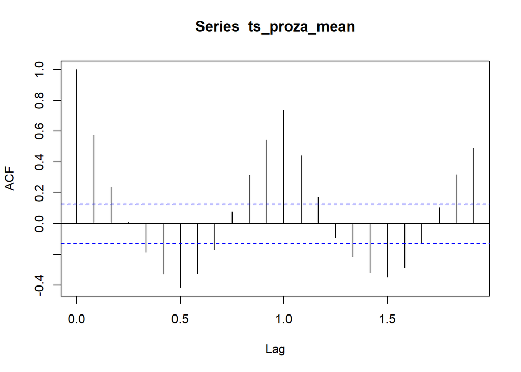

```r
#Расчет автокорреляции

#Загружаем пакет
library (feasts)

#Выполняем вычисления для сдвигов
avtocor <- acf(ts_proza_mean, pl = FALSE)

#Строим коррелограмму временного ряда для прозы
acf(ts_proza_mean)
```

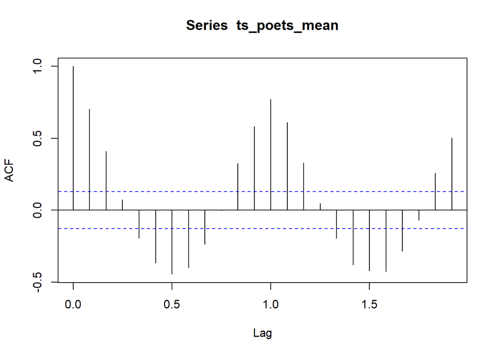

```r
#График имеет закономерности, но все же лаги иногда не совпадают

avtocor2 <- acf(ts_poets_mean, pl = FALSE)
#Строим коррелограмму временного ряда для поэзии
acf(ts_poets_mean)
```

В обоих графах есть тренд, сезонное колебание данных Лаги убывают и возрастают закономерно

### Нейросети

Продолжим предсказание будущих значений, но уже с помощью готовых нейросетей для анализа временных рядов.

NNAR-Neural Network Autoregression Model - имеет две составляющие, p обозначает количество запаздывающих значений, которые используются в качестве входных данных k обозначает количество скрытых узлов

Если набор данных сезонный, то и обозначения очень похожи NNAR(p,P,k), p подбирается по AIC, а P обозначает количество сезонных лагов

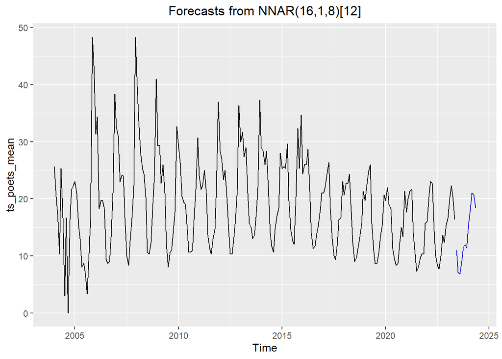

```r
library(tsibble)  #для работы с рядами по принципам tidy data
library(fable)  #для tidy прогнозирования
library(forecast)  #для функции forecast и сети nnetar
library(nnfor) #для функции mlp


set.seed(42)

nnetar_fit_poets <- nnetar(ts_poets_mean)
nnetar_pred_poets <- forecast(nnetar_fit_poets, h = 12, PI = F)
autoplot(nnetar_pred_poets) + theme(plot.title = element_text(hjust = 0.5))
```

```r
nnetar_fit_poets
```

```
## Series: ts_poets_mean
## Model:  NNAR(16,1,8)[12]
## Call:   nnetar(y = ts_poets_mean)
##
## Average of 20 networks, each of which is
## a 16-8-1 network with 145 weights
## options were - linear output units
##
## sigma^2 estimated as 0.3599
```

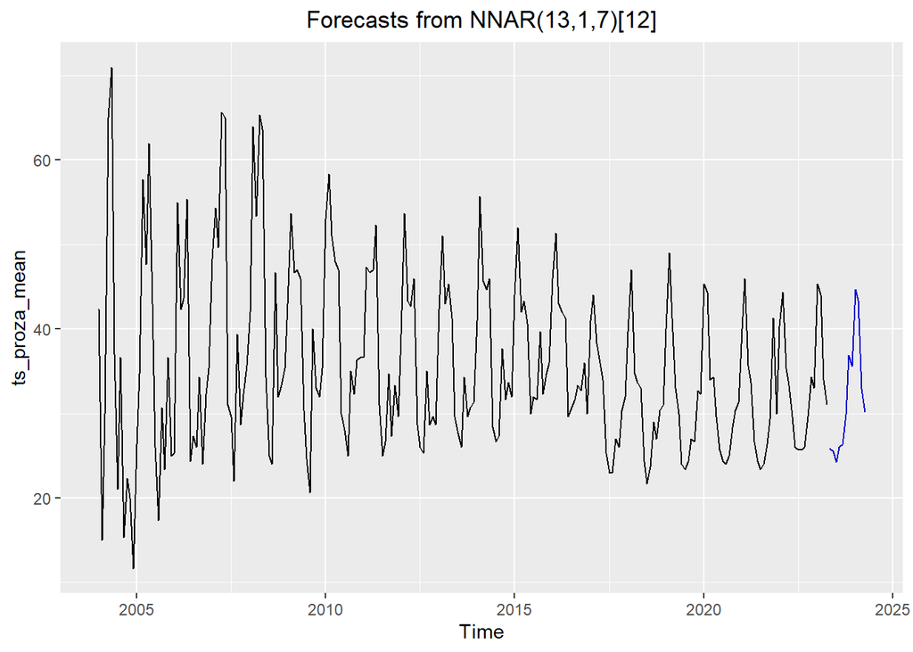

```r
nnetar_fit_proza <- nnetar(ts_proza_mean)
nnetar_pred_proza <- forecast(nnetar_fit_proza, h = 12, PI = F)
autoplot(nnetar_pred_proza) + theme(plot.title = element_text(hjust = 0.5))
```

```r
nnetar_fit_proza
```

```
## Series: ts_proza_mean
## Model:  NNAR(13,1,7)[12]
## Call:   nnetar(y = ts_proza_mean)
##
## Average of 20 networks, each of which is
## a 13-7-1 network with 106 weights
## options were - linear output units
##
## sigma^2 estimated as 1.488
```

MLP - multilayer perceptrons Автоматически считывает входные данные авторегрессии и делает необходимую предварительную обработку временного ряда. По умолчанию обучает 20 сетей, которые используются для создания ансамблевого прогноза. В конце по умолчанию дает медианное значение прогнозов. Имеет один скрытый слой с 5 узлами. По желанию можно переопределить любой из параметров.

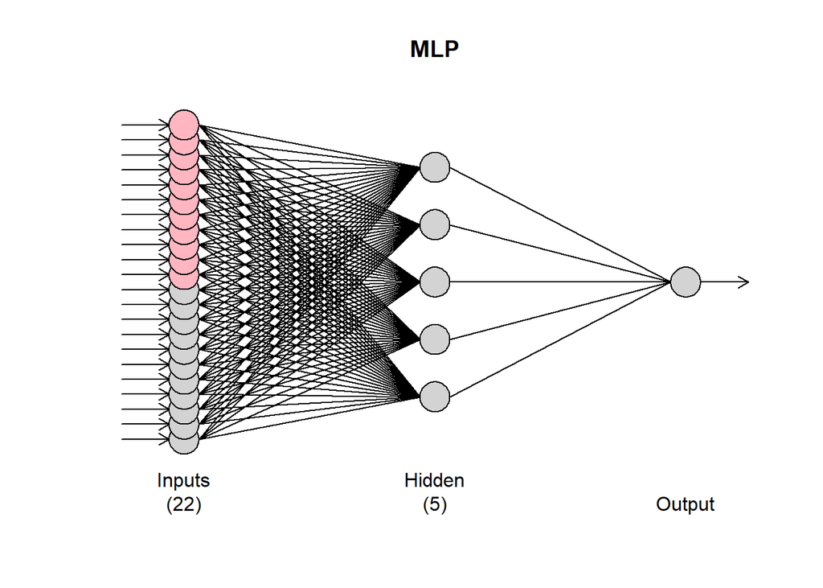

```r
mlp_fit_poets <- mlp(ts_poets_mean)
plot(mlp_fit_poets ) # так выглядит сеть (архитектура). Розовые входные данные - бинарные dummies (1-T, 0-F), используемые для кодирования сезонности, а серые — авторегрессионные лаги
```

```r
print(mlp_fit_poets )
```

```
## MLP fit with 5 hidden nodes and 20 repetitions.
## Series modelled in differences: D1.
## Univariate lags: (1,2,3,4,5,6,7,8,9,10,11)
## Deterministic seasonal dummies included.
## Forecast combined using the median operator.
## MSE: 0.8945.
```

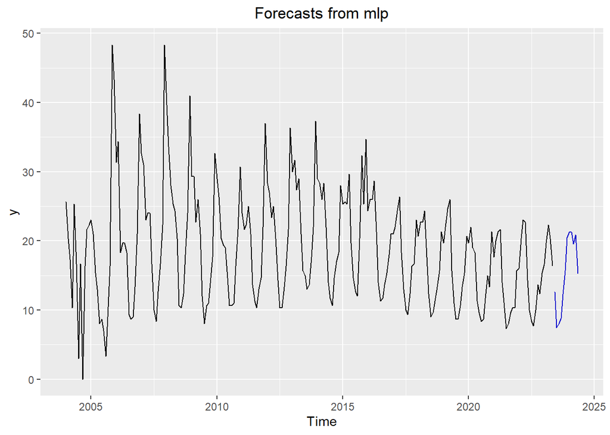

```r
mlp_pred_poets <- forecast(mlp_fit_poets)
autoplot(mlp_pred_poets) + theme(plot.title = element_text(hjust = 0.5))
```

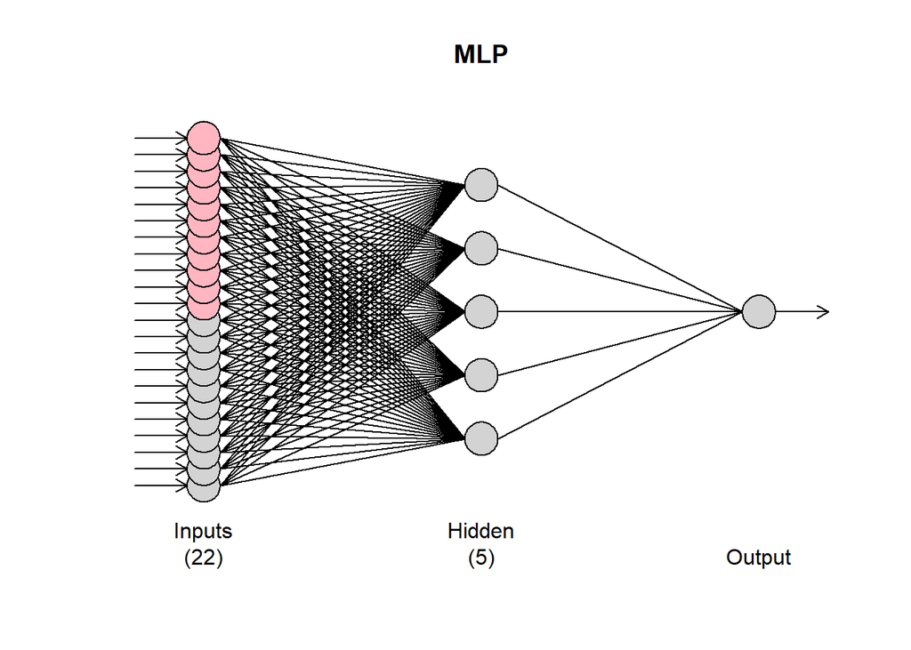

```r
mlp_fit_proza <- mlp(ts_proza_mean)
plot(mlp_fit_proza )
```

```r
print(mlp_fit_proza )
```

```
## MLP fit with 5 hidden nodes and 20 repetitions.
## Series modelled in differences: D1.
## Univariate lags: (1,2,3,4,5,6,7,8,9,10,11)
## Deterministic seasonal dummies included.
## Forecast combined using the median operator.
## MSE: 1.6805.
```

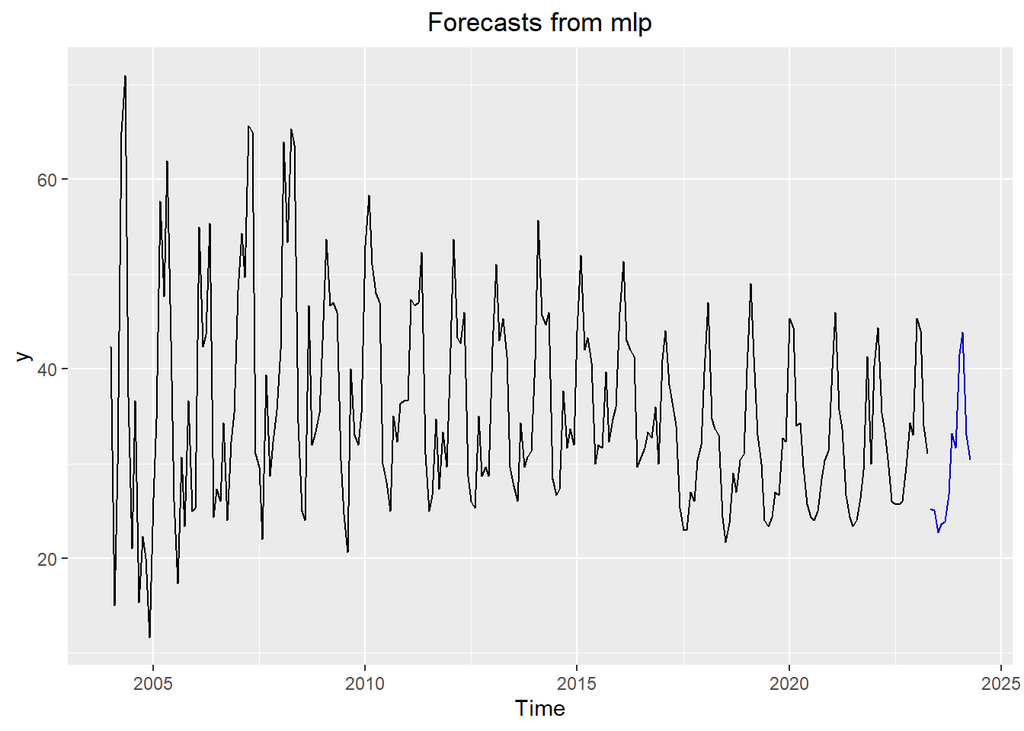

```r
mlp_pred_proza <- forecast(mlp_fit_proza)
autoplot(mlp_pred_proza) + theme(plot.title = element_text(hjust = 0.5))
```

```r
#Можно настроить количество скрытых узлов, но мы не будем. Для этого есть разные варианты, но все требуют больших вычислительных ресурсов.
```

Оценим и сравним точность всех моделей, примененных при анализе. Основным параметром для сравнения будет MAE - средняя абсолютная ошибка (модули разностей предсказанного и реального суммируются и делятся на число наблюдений) Чем она меньше - тем лучше

```r
all_models_poets=list(PoetryForecastNaive,PoetryForecastETS,PoetryForecastARIMA ,nnetar_fit_poets,mlp_pred_poets)
row_n=c("Naive","ETS","ARIMA","NNETAR","MLP")
all_poets_acc <- data.frame()
for (mod in all_models_poets){
  ac=as.data.frame(accuracy(mod))
  all_poets_acc=rbind(all_poets_acc,ac)
}
row.names(all_poets_acc)=row_n
all_poets_acc
```

```
##                  ME      RMSE       MAE       MPE    MAPE      MASE        ACF1
## Naive   0.021212121 5.1909984 3.2515152       NaN     Inf 1.0000000 -0.38647104
## ETS    -0.081256099 4.0565277 2.6376890      -Inf     Inf 0.8509916  0.25056857
## ARIMA  -0.188495916 3.7188715 2.2593014      -Inf     Inf 0.7289133 -0.03030932
## NNETAR -0.007633451 0.5999088 0.4404059 -0.403826 2.61615 0.1420872  0.15919434
## MLP    -0.002959786 0.9458062 0.6543785       Inf     Inf 0.2038228  0.09993709
```

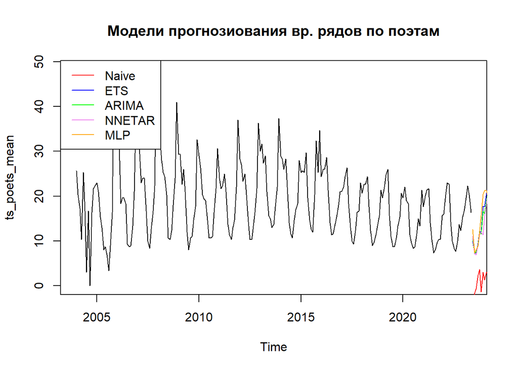

```r
plot(ts_poets_mean, main = "Модели прогнозиования вр. рядов по поэтам")
lines(poetry_Naive_f$mean, col = "red")
lines(poetry_ETS_f$mean, col = "blue")
lines(poetry_ARIMA_f$mean, col = "green")
lines(nnetar_pred_poets$mean, col = "violet")
lines(mlp_pred_poets$mean, col = "orange")
legend("topleft", row_n, col = c("red", "blue", "green","violet","orange"), lty = 1)
```

```r
all_models_proza=list(ProsaForecastNaive,ProsaForecastETS,ProsaForecastARIMA ,nnetar_fit_proza,mlp_pred_proza)
row_n=c("Naive","ETS","ARIMA","NNETAR","MLP")
all_proza_acc <- data.frame()
for (mod in all_models_proza){
  ac=as.data.frame(accuracy(mod))
  all_proza_acc=rbind(all_proza_acc,ac)
}
row.names(all_proza_acc)=row_n
all_proza_acc
```

```
##                  ME     RMSE       MAE         MPE      MAPE      MASE
## Naive   0.062404871 8.026244 4.9817352        -Inf       Inf 1.0000000
## ETS    -0.611682146 6.282672 4.0316880 -4.38563338 12.711875 0.9844299
## ARIMA  -0.093925197 5.410097 3.6032148 -0.58446543 10.209513 0.8798083
## NNETAR  0.005606528 1.219660 0.9197633 -0.27571303  2.648447 0.2245815
## MLP    -0.007939415 1.296324 0.9258794  0.01805223  2.619287 0.2206833
##                ACF1
## Naive  -0.359367731
## ETS     0.241945845
## ARIMA   0.037875630
## NNETAR  0.004879543
## MLP    -0.027087808
```

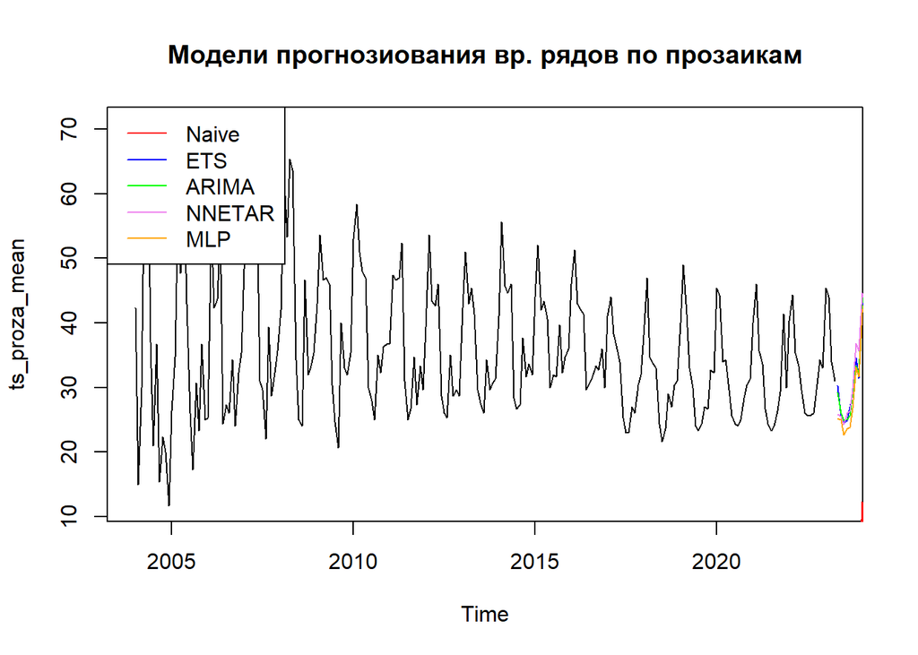

```r
plot(ts_proza_mean, main = "Модели прогнозиования вр. рядов по прозаикам")
lines(prosa_Naive_f$mean, col = "red")
lines(prosa_ETS_f$mean, col = "blue")
lines(prosa_ARIMA_f$mean, col = "green")
lines(nnetar_pred_proza$mean, col = "violet")
lines(mlp_pred_proza$mean, col = "orange")
legend("topleft", row_n, col = c("red", "blue", "green","violet","orange"), lty = 1)
```

Как видим, прогнозы, основанные на модели Naive, сработали не совсем адекватно. А все остальные довольно похожи и лишь немного отличаются степенью детализации колебаний и оптимистичностью

Наиболее точной моделью в обоих случаях является NNETAR.